# Covid19 Report

Som. Thapa

06/12/2023

## Introduction

This is part of final project for DTSA 5301 Data Science as a Field. Objective of the report is develop essential skills for data analysis ie. tidy, transform, analyze and report the conclusion

### Goal of the Project

The goal of this project is to analyze how COVID-19 spreads over time over the world and in United States. In addition, I will also explore if there is any relation between COVID-19 deaths and impact of vaccinations

### Import R libraries and set up environment

```r
# Import libraries and set options
library(tidyverse)
library(lubridate)
options(warn=-1)
options(dplyr.summarise.inform = FALSE)
knitr::opts_chunk$set(echo = TRUE)
knitr::opts_knit$set(root.dir = getwd())
```

## Data Import

### Data Source

The report makes use of publicly available data from John Hopkins university COVID-19 and vaccine data , one world data for population

1. “https://raw.githubusercontent.com/CSSEGISandData/COVID-19/master/csse_cov d_19_data/csse_covid_19_time_series/” -“time_series_covid19_confirmed_US.csv” -“time_series_covid19_confirmed_global.csv” -“time_series_covid19_deaths_US.csv” -“time_series_covid19_deaths_global.csv
2. <https://github.com/owid/covid-19-data/tree/master/public/data/vaccination s>
3. https://raw.githubusercontent.com/CSSEGISandData/COVID-19/master/csse_covi d_19_data/UID_ISO_FIPS_LookUp_Table.csv

### Import COVID019 data

```r
url_in <- "https://raw.githubusercontent.com/CSSEGISandData/COVID-19/master/csse_covid_19_data/csse_covid_19_time_series/"

file_names <- c("time_series_covid19_confirmed_global.csv",
                "time_series_covid19_deaths_global.csv",
                "time_series_covid19_confirmed_US.csv",
                "time_series_covid19_deaths_US.csv")
urls <- str_c(url_in, file_names)
global_cases <- read_csv(urls[1])
global_deaths <- read_csv(urls[2])
US_cases <- read_csv(urls[3])
US_deaths <- read_csv(urls[4])
```

### Import Vaccine Data

```r
url_in <- 'https://covid.ourworldindata.org/data/vaccinations/us_state_vaccinations.csv'

US_vaccinations <- read_csv(url_in)
```

### Import world population Data

```r
uid_lookup_url <- "https://raw.githubusercontent.com/CSSEGISandData/COVID-19/master/csse_covid_19_data/UID_ISO_FIPS_LookUp_Table.csv"

uid <- read_csv(uid_lookup_url) %>%
  select(-c(Lat, Long_, Combined_Key, code3, iso2, iso3, Admin2))
```

## Tidy and Transfrom Data

###Tidy COVID-19 Data

There are 4 data sets: global cases, global deaths, US cases, and US deaths. Each data set has the following columns: Province/State, Country/Region, Lat, Long, and hundreds of date columns.

Dates are each column which do not look useful. I will pivot dates and take count for each date.

Data Set also contains Lat and Long which are not much useful since I will use country_region to perform analysis.

### Tidy US Cases

```r
US_cases <- mutate_at(US_cases, vars(Admin2, Province_State, Country_Region), as.factor) %>%
  rename(County = 'Admin2') %>%
  pivot_longer(cols = -(UID:Combined_Key),
               names_to = 'Date',
               values_to = 'Cases') %>%
  filter(Cases >= 0) %>%
  select(County:Cases) %>%
  mutate(Date = mdy(Date)) %>%
  select(-c(Lat, Long_))


US_deaths <- mutate_at(US_deaths, vars(Admin2, Province_State, Country_Region), as.factor) %>%
  rename(County = 'Admin2') %>%
  pivot_longer(cols = -(UID:Population),
               names_to = 'Date',
               values_to = 'Deaths') %>%
  filter(Deaths >= 0) %>%
  select(County:Deaths) %>%
  mutate(Date = mdy(Date)) %>%
  select(-c(Lat, Long_))

US <- US_cases %>%
  full_join(US_deaths)

# Summarizing cases and deaths by state

US_by_state <- US %>%
  group_by(Province_State, Country_Region, Date) %>%
  summarize(Cases = sum(Cases), Deaths = sum(Deaths), Population = sum(Population)) %>%
  select(Province_State, Country_Region, Date, Cases, Deaths, Population) %>%
  ungroup()

# Summarizing cases and deaths per 100 by state
# This transformation is done to match with vaccine data which are also in per_hundred

US_by_state_deaths_per_hundred <- US_by_state %>%
  group_by(Province_State, Population) %>%
  summarize(Deaths = max(Deaths)) %>%
  mutate(Deaths_per_hundred = (Deaths/Population)*100) %>%
  arrange(desc(Deaths_per_hundred)) %>%
  filter(Population > 0) %>%
  select(Province_State, Population, Deaths, Deaths_per_hundred) %>%
  ungroup()
```

### Tidy Global COVID-19 Data

```r
global_cases <- global_cases %>%
  pivot_longer(cols = -c('Province/State',
                         'Country/Region', Lat, Long),
               names_to = "date",
               values_to = "cases") %>%
  select(-c(Lat, Long))


global_deaths <- global_deaths %>%
  pivot_longer(cols = -c('Province/State',
                         'Country/Region', Lat, Long),
               names_to = "date",
               values_to = "deaths") %>%
  select(-c(Lat, Long))

global <- global_cases %>%
  full_join(global_deaths) %>%
  rename(Country_Region = 'Country/Region',
         Province_State = 'Province/State') %>%
  mutate(date = mdy(date))
# Filter out and keep only where the cases are positive
global <- global %>% filter(cases > 0)

global <- global %>%
  unite("Combined_Key",
        c(Province_State, Country_Region),
        sep = ", ",
        na.rm = TRUE,
        remove = FALSE)
# Join global  with global population lookup table df and remove unneeded columns

global <- global %>%
    left_join(uid, by = c('Province_State', 'Country_Region')) %>%
    select(-c(UID, FIPS)) %>%
    select(Province_State, Country_Region, date,
        cases , deaths, Population, Combined_Key)

global_by_country <- global %>%
  group_by(Country_Region, date) %>%
  summarize(cases = sum(cases), deaths = sum(deaths),
            Population = sum(Population)) %>%
  mutate(deaths_per_mill = deaths *1000000 / Population) %>%
  select(Country_Region, date, cases, deaths, deaths_per_mill, Population) %>%
  ungroup()

global_totals <- global_by_country %>%
  group_by(Country_Region, date) %>%
  summarize(cases = sum(cases), deaths = sum(deaths),
            Population = sum(Population)) %>%
  mutate(deaths_per_mill = deaths *1000000 / Population) %>%
  select(Country_Region, date, cases, deaths, deaths_per_mill, Population) %>%
  ungroup()
global_totals
```

```
## # A tibble: 214,113 × 6
##    Country_Region date       cases deaths deaths_per_mill Population
##    <chr>          <date>     <dbl>  <dbl>           <dbl>      <dbl>
##  1 Afghanistan    2020-02-24     5      0               0   38928341
##  2 Afghanistan    2020-02-25     5      0               0   38928341
##  3 Afghanistan    2020-02-26     5      0               0   38928341
##  4 Afghanistan    2020-02-27     5      0               0   38928341
##  5 Afghanistan    2020-02-28     5      0               0   38928341
##  6 Afghanistan    2020-02-29     5      0               0   38928341
##  7 Afghanistan    2020-03-01     5      0               0   38928341
##  8 Afghanistan    2020-03-02     5      0               0   38928341
##  9 Afghanistan    2020-03-03     5      0               0   38928341
## 10 Afghanistan    2020-03-04     5      0               0   38928341
## # … with 214,103 more rows
```

### Tidy Vaccine data

```r
US_vaccinations <- US_vaccinations %>%
  select(-c(total_distributed, people_vaccinated, people_fully_vaccinated,
          daily_vaccinations_raw, daily_vaccinations,daily_vaccinations_per_million,
          share_doses_used, total_boosters)) %>%
  rename(Province_State = 'location')

US_by_state_vaccinations_per_hundred <- US_vaccinations %>%
  group_by(Province_State) %>%
  mutate(Province_State = fct_recode(Province_State,
                                     "New York" = "New York State")) %>%
  summarize(people_fully_vaccinated_per_hundred = max(people_fully_vaccinated_per_hundred, na.rm = T),
            total_vaccinations_per_hundred = max(total_vaccinations_per_hundred, na.rm = T),
            people_vaccinated_per_hundred = max(people_vaccinated_per_hundred, na.rm = T),
            distributed_per_hundred = max(distributed_per_hundred, na.rm = T),
            total_boosters_per_hundred = max(total_boosters_per_hundred, na.rm = T))

US_by_state_deaths_vaccinations_per_hundred <- US_by_state_deaths_per_hundred %>%
  full_join(US_by_state_vaccinations_per_hundred) %>%
  filter(Population > 0)
```

## Data Visualization

### Visualize and Analysis of Global Data

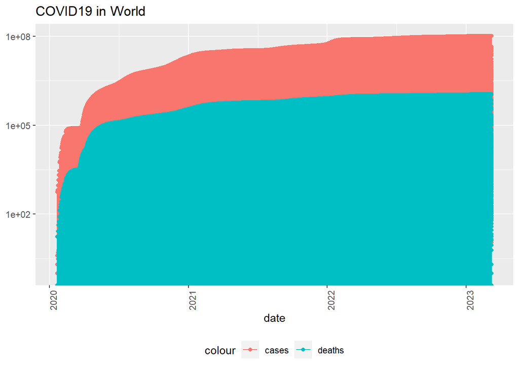

```r
global_by_country %>%
  ggplot(aes(x = date , y = cases)) +

  geom_line(aes(color = "cases")) +
  geom_point(aes(color = "cases")) +

  geom_line(aes(y = deaths, color = "deaths")) +
  geom_point(aes(y = deaths, color = "deaths")) +

  scale_y_log10() +

  theme(legend.position = "bottom",
        axis.text.x = element_text(angle = 90)) +

  labs(title = "COVID19 in World", y = NULL)
```

*Observation and Discussion*

The plot shows the trend of cumulative COVID-19 and related fatalities for all over the world. Cases were recorded from early 2020 and it went sharply up and then stabilize after early part of 2022.

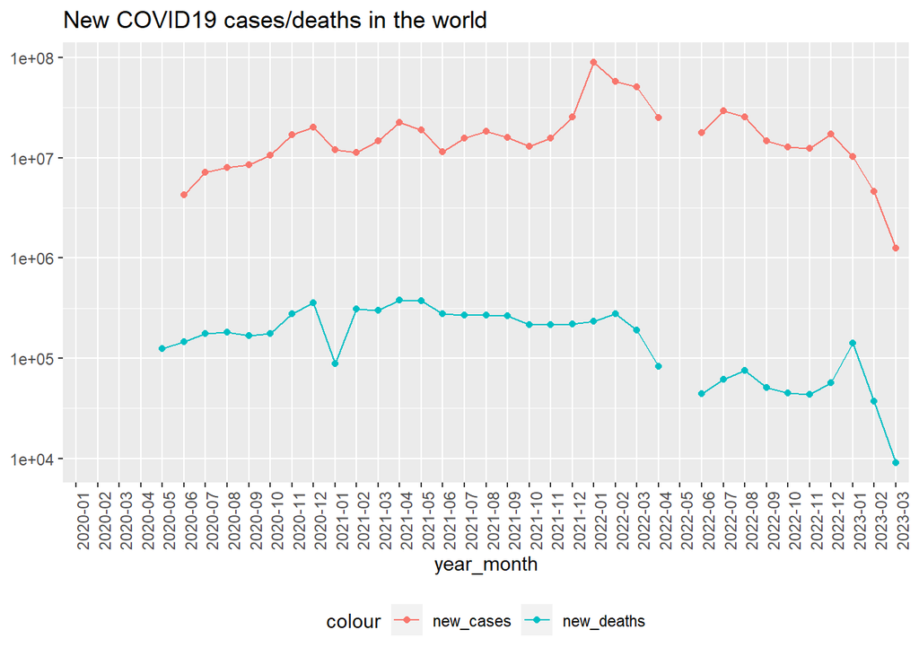

```r
trend<- global_totals %>%
  filter(cases > 0) %>%
  mutate(new_cases = cases  - lag(cases , default=0),
         new_deaths = deaths - lag(deaths),
         year_month = format_ISO8601(date, precision = "ym"))  %>%
  group_by(year_month)  %>%
  summarize(new_cases = sum(new_cases), new_deaths = sum(new_deaths)) %>%
  ungroup()
trend %>%
  ggplot(aes(x = year_month, y = new_cases)) +
  geom_line(aes(color = "new_cases", group = 1)) +
  geom_point(aes(color = "new_cases")) +
  geom_line(aes(y = new_deaths, color = "new_deaths", group = 1)) +
  geom_point(aes(y = new_deaths, color = "new_deaths")) +
  scale_y_log10() +
  theme(legend.position = "bottom",
        axis.text.x = element_text(angle = 90)) +
  labs(title = "New COVID19 cases/deaths in the world", y = NULL)
```

### Visualize and Analysis US Data

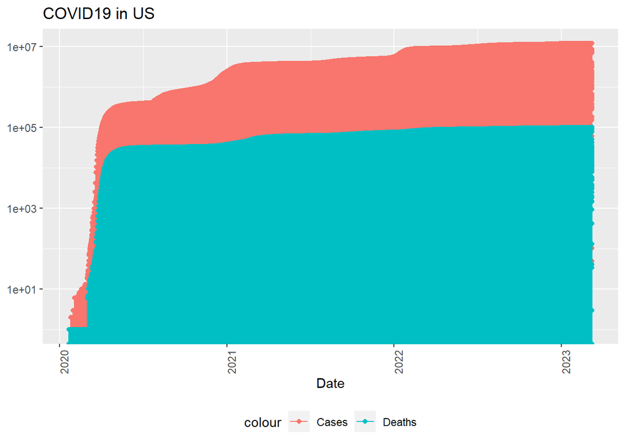

```r
US_by_state %>%
  ggplot(aes(x = Date , y = Cases)) +

  geom_line(aes(color = "Cases")) +
  geom_point(aes(color = "Cases")) +

  geom_line(aes(y = Deaths, color = "Deaths")) +
  geom_point(aes(y = Deaths, color = "Deaths")) +

  scale_y_log10() +

  theme(legend.position = "bottom",
        axis.text.x = element_text(angle = 90)) +

  labs(title = "COVID19 in US", y = NULL)
```

*Observation and Discussion*

The US cumulative plot follows similar progression as Global COVID-19 trend

[figure not shown]

```r
trend_US<- US %>%
  filter(Cases > 0) %>%
  mutate(new_cases = Cases  - lag(Cases , default=0),
         new_deaths = Deaths - lag(Deaths),
         year_month = format_ISO8601(Date, precision = "ym"))  %>%
  group_by(year_month)  %>%
  summarize(new_cases = sum(new_cases), new_deaths = sum(new_deaths)) %>%
  ungroup()
trend %>%
  ggplot(aes(x = year_month, y = new_cases)) +
  geom_line(aes(color = "new_cases", group = 1)) +
  geom_point(aes(color = "new_cases")) +
  geom_line(aes(y = new_deaths, color = "new_deaths", group = 1)) +
  geom_point(aes(y = new_deaths, color = "new_deaths")) +
  scale_y_log10() +
  theme(legend.position = "bottom",
        axis.text.x = element_text(angle = 90)) +
  labs(title = "New COVID19 cases/deaths in the US", y = NULL)
```

*Observation and Discussion*

### Visualize and Analysise Vaccine Data***

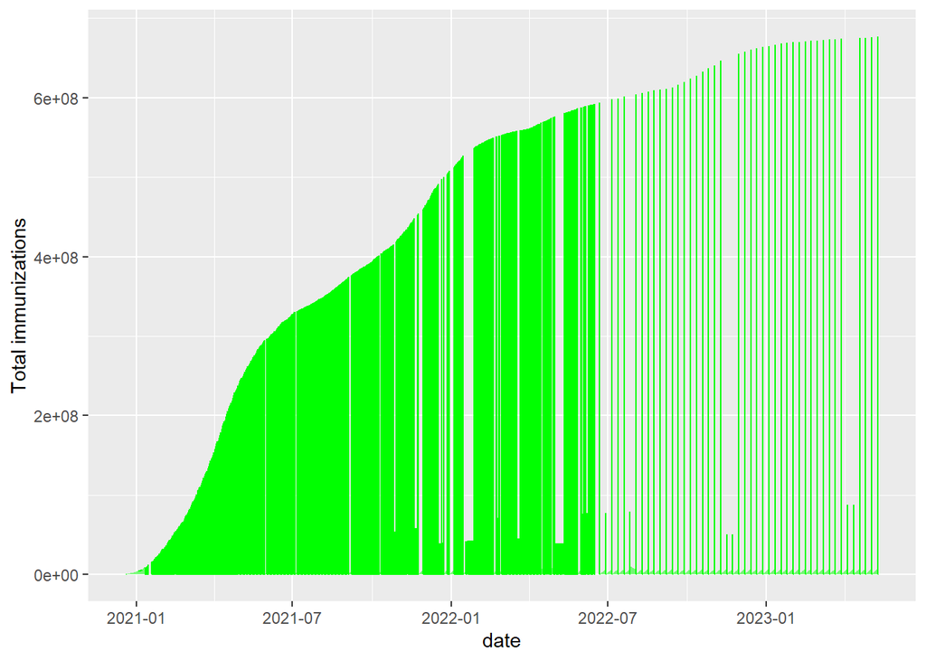

```r
US_vaccinations %>%
  ggplot( aes(x=date, y=as.numeric(total_vaccinations))) +
  geom_area(fill="Green", alpha=0.5) +
  geom_line(color="Green") +
  ylab("Total immunizations")
```

*Observations and Discussion*

# MODELING

### Modeling of Global data

For this model, a simple linear regression is performed for death for thousand and case per thousand in the global data.

```r
global_country_totals <- global_by_country %>%
  group_by(Country_Region) %>%
  summarize(deaths = max(deaths), cases = max(cases),
            population = max(Population),
            cases_per_thou = 1000 * cases/population,
            deaths_per_thou = 1000 * deaths / population) %>%
  filter(cases > 0, population > 0)

mod <- lm(deaths_per_thou ~ cases_per_thou, data = global_country_totals)
summary(mod)
```

```
##
## Call:
## lm(formula = deaths_per_thou ~ cases_per_thou, data = global_country_totals)
##
## Residuals:
##     Min      1Q  Median      3Q     Max
## -2.4069 -0.6090 -0.3898  0.4689  5.5423
##
## Coefficients:
##                 Estimate Std. Error t value Pr(>|t|)
## (Intercept)    0.6277935  0.1116605   5.622 6.57e-08 ***
## cases_per_thou 0.0035877  0.0004393   8.167 4.13e-14 ***
## ---
## Signif. codes:  0 '***' 0.001 '**' 0.01 '*' 0.05 '.' 0.1 ' ' 1
##
## Residual standard error: 1.151 on 192 degrees of freedom
## Multiple R-squared:  0.2578, Adjusted R-squared:  0.254
## F-statistic:  66.7 on 1 and 192 DF,  p-value: 4.127e-14
```

```r
global_country_totals %>% slice_min(cases_per_thou)
```

```
## # A tibble: 1 × 6
##   Country_Region deaths cases population cases_per_thou deaths_per_thou
##   <chr>           <dbl> <dbl>      <dbl>          <dbl>           <dbl>
## 1 Korea, North        6     1   25778815      0.0000388        0.000233
```

```r
global_country_totals %>% slice_max(cases_per_thou)
```

```
## # A tibble: 1 × 6
##   Country_Region deaths cases population cases_per_thou deaths_per_thou
##   <chr>           <dbl> <dbl>      <dbl>          <dbl>           <dbl>
## 1 San Marino        122 23616      33938           696.            3.59
```

```r
x_grid <- seq(1, 151)
new_df <- tibble(cases_per_thou = x_grid)
global_country_totals %>% mutate(pred = predict(mod))
```

```
## # A tibble: 194 × 7
##    Country_Region      deaths    cases population cases_per_thou deaths_…¹  pred
##    <chr>                <dbl>    <dbl>      <dbl>          <dbl>     <dbl> <dbl>
##  1 Afghanistan           7896   209451   38928341           5.38    0.203  0.647
##  2 Albania               3598   334457    2877800         116.      1.25   1.04
##  3 Algeria               6881   271496   43851043           6.19    0.157  0.650
##  4 Andorra                165    47890      77265         620.      2.14   2.85
##  5 Angola                1933   105288   32866268           3.20    0.0588 0.639
##  6 Antigua and Barbuda    146     9106      97928          93.0     1.49   0.961
##  7 Argentina           130472 10044957   45195777         222.      2.89   1.43
##  8 Armenia               8727   447308    2963234         151.      2.95   1.17
##  9 Australia            19574 11399460   25459700         448.      0.769  2.23
## 10 Austria              21970  5961143    9006400         662.      2.44   3.00
## # … with 184 more rows, and abbreviated variable name ¹deaths_per_thou
```

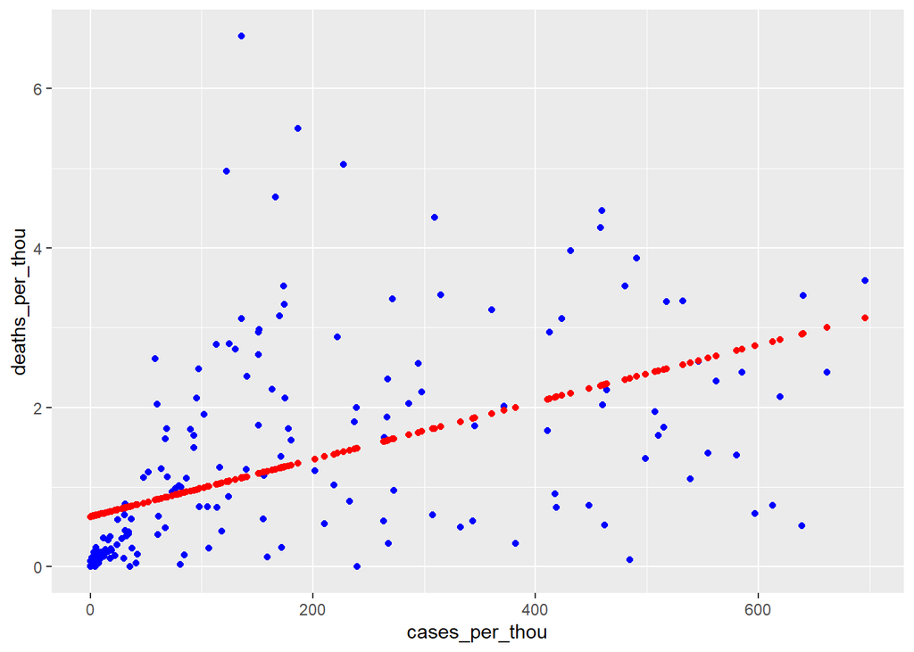

```r
global_tot_w_pred <- global_country_totals %>% mutate(pred = predict(mod))
global_tot_w_pred %>% ggplot() +
  geom_point(aes(x = cases_per_thou, y = deaths_per_thou), color = "blue") +
  geom_point(aes(x = cases_per_thou, y = pred), color = "red")
```

```r
labs(x = "Cases Per thousand",
       y = "Deaths for thousand",
       title = "Cases Per thousand/ Deaths per thousand  - Linear Model for Globe")
```

```
## $x
## [1] "Cases Per thousand"
##
## $y
## [1] "Deaths for thousand"
##
## $title
## [1] "Cases Per thousand/ Deaths per thousand  - Linear Model for Globe"
##
## attr(,"class")
## [1] "labels"
```

*Observations and Discussion*

### Modeling for US Data

For this model, a simple linear regression is performed on the data for COVID-19 vaccination rates and death rates in the US to see if there a significant relationship between the number of people fully vaccinated and number of deaths.The above graph shows the downward trend between fully vaccinated people per 100 members and deaths per 100 members.

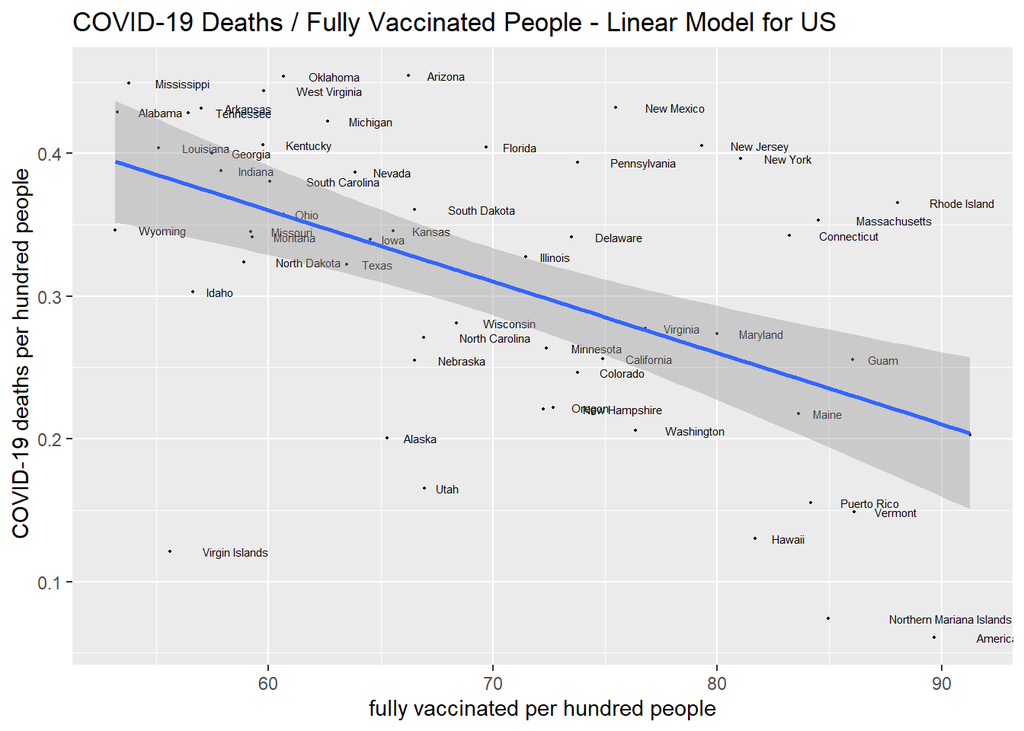

```r
ggplot(data = US_by_state_deaths_vaccinations_per_hundred,
       aes(x = people_fully_vaccinated_per_hundred,
           y = Deaths_per_hundred,
           label = Province_State)) +
  geom_point(size = .4) +
  geom_text(size = 2, vjust = .5, hjust = -.5) +
  geom_smooth(method = "lm") +
  labs(x = "fully vaccinated per hundred people",
       y = " COVID-19 deaths per hundred people",
       title = "COVID-19 Deaths / Fully Vaccinated People - Linear Model for US")
```

```r
mod1 <- lm(Deaths_per_hundred ~ people_fully_vaccinated_per_hundred,
          data = US_by_state_deaths_vaccinations_per_hundred)
summary(mod1)
```

```
##
## Call:
## lm(formula = Deaths_per_hundred ~ people_fully_vaccinated_per_hundred,
##     data = US_by_state_deaths_vaccinations_per_hundred)
##
## Residuals:
##       Min        1Q    Median        3Q       Max
## -0.261032 -0.049752  0.007771  0.051880  0.149193
##
## Coefficients:
##                                      Estimate Std. Error t value Pr(>|t|)
## (Intercept)                          0.659862   0.076443   8.632 9.54e-12 ***
## people_fully_vaccinated_per_hundred -0.004994   0.001088  -4.590 2.68e-05 ***
## ---
## Signif. codes:  0 '***' 0.001 '**' 0.01 '*' 0.05 '.' 0.1 ' ' 1
##
## Residual standard error: 0.08772 on 54 degrees of freedom
## Multiple R-squared:  0.2807, Adjusted R-squared:  0.2674
## F-statistic: 21.07 on 1 and 54 DF,  p-value: 2.68e-05
```

*Observations and Discussion*

The summary statistics shows p-value for people_fully_vaccinated_per_hundred ***2.68e-05** which is way below the bar p-value 0.05 from which we can reject null hypothesis ie there is correlation between Deaths and people fully vaccinated

# CONCLUSION

From the first liner model on the global data, we can conclude there is linear relationship be between number of cases and number of deaths

From the second model observations, we can safely conclude there is statistically significant relationship in the US between the number of people in a state that are fully vaccinated for COVID-19 and the number of COVID-19 deaths in that state

# BIAS

There can be a bias in how the data has been collected. For example many people who live in remote area most probably did not go for the testing. In addition, there are no additional data points other than death and cases.Multiple research show that majority death due to COVID-19 with people with other co-morbidity.